# Comprehensive Analysis: Youth Employment, GDP Growth, and SDG 8 Targets

Data Science Project

2025-12-10

# 1. Introduction

This analysis explores global economic growth patterns and youth employment challenges through multiple lenses:

- **Continental GDP per capita growth** using rolling CAGR analysis
- **LDC performance** against SDG 8.1 (7% GDP growth target)
- **COVID-19 impact** on LDC growth assessments
- **Youth NEET rates** (Not in Education, Employment, or Training) across continents

The analysis uses data from the World Bank, UN Population Division, and Our World in Data.

## Data Requirements

The following CSV files should be present in your working directory:

1. `continents-according-to-our-world-in-data.csv` - Country-continent classifications
2. `gdp-per-capita-worldbank.csv` - GDP per capita data (PPP, constant 2017 international $)
3. `youth-not-in-education-employment-training.csv` - NEET rates by country and year
4. `processed_population_un_countries.csv` - UN population data (processed format)
5. `processed_population_un_countries_wide.csv` - UN population data (wide format, optional)

# 2. Setup and Data Loading

## 2.1 Load Required Libraries

```r
# Data manipulation and visualization
library(tidyverse)
library(ggplot2)
library(scales)
library(dplyr)
library(stringr)
library(janitor)
```

## 2.2 Load Core Datasets

All CSV files are assumed to be in the current working directory.

```r
# Load continent classifications
continents <- read_csv("continents-according-to-our-world-in-data.csv") %>%
  clean_names() %>%
  rename(country = entity, iso3 = code, continent = continent) %>%
  filter(continent != "Antarctica")

# Load GDP per capita data
gdp_pc <- read_csv("gdp-per-capita-worldbank.csv") %>%
  clean_names() %>%
  rename(
    country = entity,
    iso3 = code,
    year = year,
    gdp_pc_ppp_2017usd = gdp_per_capita_ppp_constant_2017_international
  ) %>%
  mutate(year = as.integer(year))

# Alternative name for compatibility with other analyses
gdp <- gdp_pc %>%
  rename(GDP_per_capita = gdp_pc_ppp_2017usd)

# Load NEET data
neet <- read_csv("youth-not-in-education-employment-training.csv") %>%
  clean_names() %>%
  rename(
    country = entity,
    iso3 = code,
    year = year,
    neet_pct = share_of_youth_not_in_education_employment_or_training_total_percent_of_youth_population
  ) %>%
  mutate(year = as.integer(year))

# Load processed UN population data
population <- read_csv("processed_population_un_countries.csv")

# Extract total population by country and year
clean_pop <- population %>%
  select(CountryName, Year, TotalPopulation) %>%
  distinct() %>%
  rename(country = CountryName, population = TotalPopulation, year = Year)

# Create ISO3 mapping from continents dataset
iso3_mapping <- continents %>%
  select(country, iso3) %>%
  distinct()

# Add ISO3 codes to population data
clean_pop <- clean_pop %>%
  left_join(iso3_mapping, by = "country") %>%
  filter(!is.na(iso3)) %>%
  mutate(year = as.integer(year))

# Extract youth population (ages 15-24) for weighting
clean_pop_by_age <- population %>%
  filter(AgeGroup %in% c("15-19", "20-24")) %>%
  group_by(CountryName, Year) %>%
  summarise(
    population_15_24 = sum(Population, na.rm = TRUE),
    .groups = "drop"
  ) %>%
  rename(country = CountryName, year = Year) %>%
  left_join(iso3_mapping, by = "country") %>%
  filter(!is.na(iso3)) %>%
  mutate(year = as.integer(year))

# Also create population summary for continental analysis
population_summary <- population %>%
  select(CountryName, Year, TotalPopulation) %>%
  distinct() %>%
  rename(Entity = CountryName)

cat("✓ Data loaded successfully\n")
```

```
## ✓ Data loaded successfully
```

```r
cat("  - Continents:", n_distinct(continents$iso3), "countries\n")
```

```
##   - Continents: 281 countries
```

```r
cat("  - GDP data:", nrow(gdp_pc), "observations\n")
```

```
##   - GDP data: 6346 observations
```

```r
cat("  - NEET data:", nrow(neet), "observations\n")
```

```
##   - NEET data: 1908 observations
```

```r
cat("  - Population data (total):", n_distinct(clean_pop$iso3), "countries\n")
```

```
##   - Population data (total): 174 countries
```

```r
cat("  - Population data (youth 15-24):", n_distinct(clean_pop_by_age$iso3), "countries\n")
```

```
##   - Population data (youth 15-24): 174 countries
```

## 2.3 Define LDC Classification

The United Nations designates countries as Least Developed Countries (LDCs) based on criteria including low per capita income, human resource weakness, and economic vulnerability.

```r
# Official UN LDC list (44 countries as of December 2024)
# Note: São Tomé and Príncipe (STP) graduated in 2024
ldc_codes <- c(
  # Africa (32)
  "AGO", "BEN", "BFA", "BDI", "CAF", "TCD", "COM", "COD", "DJI", "ERI",
  "ETH", "GMB", "GIN", "GNB", "LSO", "LBR", "MDG", "MWI", "MLI", "MRT",
  "MOZ", "NER", "RWA", "SEN", "SLE", "SOM", "SSD", "SDN", "TGO", "UGA",
  "TZA", "ZMB",
  # Asia (8)
  "AFG", "BGD", "KHM", "LAO", "MMR", "NPL", "TLS", "YEM",
  # Caribbean (1)
  "HTI",
  # Pacific (3)
  "KIR", "SLB", "TUV"
)

cat("✓ LDC classification defined:", length(ldc_codes), "countries\n")
```

```
## ✓ LDC classification defined: 44 countries
```

# 3. Results and Analysis

## 3.1 Continental GDP Per Capita Growth Analysis

This section presents rolling Compound Annual Growth Rate (CAGR) analysis from 1990-2023, showing how each continent’s growth trajectory evolved through the SDG period (2015-2023).

### 3.1.1 Prepare Continental Data

```r
# Merge GDP with continents
gdp_continents <- gdp %>%
  left_join(continents %>% select(iso3, continent), by = "iso3") %>%
  filter(continent != "Antarctica", !is.na(continent)) %>%
  filter(year >= 1990, year <= 2023)

# Merge with population data
gdp_complete <- gdp_continents %>%
  left_join(population_summary, by = c("country" = "Entity", "year" = "Year"))

cat("✓ Continental data prepared\n")
```

```
## ✓ Continental data prepared
```

```r
cat("  - Observations:", nrow(gdp_complete), "\n")
```

```
##   - Observations: 5898
```

```r
cat("  - Countries with population data:",
    round(sum(!is.na(gdp_complete$TotalPopulation)) / nrow(gdp_complete) * 100, 1), "%\n")
```

```
##   - Countries with population data: 87.1 %
```

### 3.1.2 Calculate Rolling CAGR

Rolling CAGR measures cumulative growth from each country’s earliest available data point to each subsequent year.

```r
rolling_cagr <- gdp_complete %>%
  group_by(country, iso3, continent) %>%
  arrange(year) %>%
  mutate(
    # Baseline is the earliest year with data
    Baseline_Year = first(year),
    Baseline_GDP = first(GDP_per_capita),
    Years_Since_Baseline = year - Baseline_Year,
    # Calculate CAGR: ((GDP_current / GDP_baseline)^(1/years)) - 1
    Rolling_CAGR = if_else(
      Years_Since_Baseline > 0 & !is.na(Baseline_GDP),
      ((GDP_per_capita / Baseline_GDP)^(1/Years_Since_Baseline) - 1) * 100,
      NA_real_
    )
  ) %>%
  ungroup() %>%
  filter(!is.na(Rolling_CAGR))

cat("✓ Rolling CAGR calculated for", n_distinct(rolling_cagr$country), "countries\n")
```

```
## ✓ Rolling CAGR calculated for 194 countries
```

### 3.1.3 Calculate Continental Averages

```r
# Simple average (unweighted)
simple_avg <- rolling_cagr %>%
  group_by(continent, year) %>%
  summarise(
    Avg_CAGR = mean(Rolling_CAGR, na.rm = TRUE),
    N_Countries = n(),
    .groups = "drop"
  )

# Weighted average (by population)
weighted_avg <- rolling_cagr %>%
  filter(!is.na(TotalPopulation)) %>%
  group_by(continent, year) %>%
  summarise(
    Total_Continent_Pop = sum(TotalPopulation, na.rm = TRUE),
    Weighted_CAGR = sum(Rolling_CAGR * TotalPopulation, na.rm = TRUE) / Total_Continent_Pop,
    N_Countries_With_Pop = n(),
    .groups = "drop"
  )

cat("✓ Continental CAGR averages calculated\n")
```

```
## ✓ Continental CAGR averages calculated
```

### 3.1.4 Visualize Rolling CAGR: Simple Average

```r
# Plot: Simple Average
plot_simple <- ggplot(simple_avg, aes(x = year, y = Avg_CAGR, color = continent, group = continent)) +
  annotate("rect", xmin = 2015, xmax = 2023, ymin = -Inf, ymax = Inf,
           fill = "gray90", alpha = 0.5) +
  geom_vline(xintercept = 2015, linetype = "dashed", color = "black", linewidth = 0.8) +
  annotate("text", x = 2015, y = Inf, label = "UN SDG 8\nAdopted",
           vjust = 1.2, hjust = -0.1, size = 3.5, fontface = "bold") +
  geom_hline(yintercept = 0, linetype = "dotted", color = "gray40") +
  geom_line(linewidth = 1.2) +
  geom_point(size = 0.8) +
  scale_x_continuous(breaks = seq(1990, 2023, 5), limits = c(1990, 2023)) +
  scale_y_continuous(labels = percent_format(scale = 1)) +
  scale_color_brewer(palette = "Set2") +
  labs(
    title = "Continental GDP Per Capita Growth (Simple Average)",
    subtitle = "Rolling CAGR from each country's earliest available baseline (1990-2023)",
    x = "Year",
    y = "Rolling CAGR (%)",
    color = "Continent",
    caption = "Simple average of all countries. Shaded region indicates SDG period (2015-2023)."
  ) +
  theme_minimal(base_size = 12) +
  theme(legend.position = "right")
print(plot_simple)
```

[figure not shown]

```r
ggsave("output/figures/continental_rolling_cagr_simple.png", plot_simple, width = 12, height = 7)
```

### 3.1.5 Visualize Rolling CAGR: Weighted Average

```r
# Plot: Weighted Average
plot_weighted <- ggplot(weighted_avg, aes(x = year, y = Weighted_CAGR, color = continent, group = continent)) +
  annotate("rect", xmin = 2015, xmax = 2023, ymin = -Inf, ymax = Inf,
           fill = "gray90", alpha = 0.5) +
  geom_vline(xintercept = 2015, linetype = "dashed", color = "black", linewidth = 0.8) +
  annotate("text", x = 2015, y = Inf, label = "UN SDG 8\nAdopted",
           vjust = 1.2, hjust = -0.1, size = 3.5, fontface = "bold") +
  geom_hline(yintercept = 0, linetype = "dotted", color = "gray40") +
  geom_line(linewidth = 1.2) +
  geom_point(size = 0.8) +
  scale_x_continuous(breaks = seq(1990, 2023, 5), limits = c(1990, 2023)) +
  scale_y_continuous(labels = percent_format(scale = 1)) +
  scale_color_brewer(palette = "Set2") +
  labs(
    title = "Continental GDP Per Capita Growth (Population-Weighted)",
    subtitle = "Rolling CAGR from earliest baseline, weighted by population (1990-2023)",
    x = "Year",
    y = "Rolling CAGR (%)",
    color = "Continent",
    caption = "Weighted by population: larger countries have more influence. Shaded region = SDG period."
  ) +
  theme_minimal(base_size = 12) +
  theme(legend.position = "right")
print(plot_weighted)
```

[figure not shown]

```r
ggsave("output/figures/continental_rolling_cagr_weighted.png", plot_weighted, width = 12, height = 7)
```

## 3.2 LDC Performance Against SDG 8.1 (7% GDP Growth Target)

**SDG 8.1** aims to sustain per capita economic growth in accordance with national circumstances and, in particular, at least 7 percent gross domestic product growth per annum in the least developed countries.

### 3.2.1 Prepare LDC-Specific Data

```r
# Merge GDP with continent information and add LDC status
gdp_analysis <- gdp %>%
  left_join(continents %>% select(iso3, continent), by = "iso3") %>%
  filter(continent != "Antarctica", !is.na(continent)) %>%
  mutate(LDC_Status = ifelse(iso3 %in% ldc_codes, "LDC", "Non-LDC"))

# Filter for SDG period (2015-2023)
sdg_data <- gdp_analysis %>%
  filter(year >= 2015, year <= 2023)

cat("✓ LDC data prepared\n")
```

```
## ✓ LDC data prepared
```

```r
cat("  - Total LDCs in dataset:", sum(gdp_analysis$LDC_Status == "LDC" & gdp_analysis$year == 2023), "\n")
```

```
##   - Total LDCs in dataset: 0
```

### 3.2.2 Calculate CAGR for LDCs

Compound Annual Growth Rate (CAGR) provides a smoothed annual growth rate over the entire period, removing year-to-year volatility.

```r
# Calculate CAGR for each LDC during SDG period
gdp_cagr <- sdg_data %>%
  filter(LDC_Status == "LDC") %>%
  group_by(country, iso3, continent) %>%
  arrange(year) %>%
  filter(n() >= 3) %>%  # Need at least 3 years of data
  summarise(
    Start_Year = first(year),
    End_Year = last(year),
    Start_GDP = first(GDP_per_capita),
    End_GDP = last(GDP_per_capita),
    Years_Span = End_Year - Start_Year,
    CAGR = ((End_GDP / Start_GDP)^(1/Years_Span) - 1) * 100,
    Achieved_Target = CAGR >= 7,
    .groups = "drop"
  )

# Summary statistics
achievement_summary <- gdp_cagr %>%
  summarise(
    Total_LDCs = n(),
    LDCs_Above_7 = sum(Achieved_Target),
    LDCs_Below_7 = sum(!Achieved_Target),
    Percent_Above_7 = (LDCs_Above_7 / Total_LDCs) * 100,
    Mean_CAGR = mean(CAGR),
    Median_CAGR = median(CAGR)
  )

print(achievement_summary)
```

```
## # A tibble: 1 × 6
##   Total_LDCs LDCs_Above_7 LDCs_Below_7 Percent_Above_7 Mean_CAGR Median_CAGR
##        <int>        <int>        <int>           <dbl>     <dbl>       <dbl>
## 1         41            1           40            2.44     0.879       0.901
```

### 3.2.3 Visualizations: LDC Performance

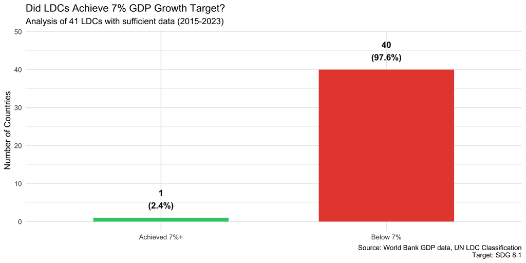

```r
# Plot 1: Overall Achievement
achievement_data <- data.frame(
  Category = c("Achieved 7%+", "Below 7%"),
  Count = c(achievement_summary$LDCs_Above_7, achievement_summary$LDCs_Below_7),
  Percentage = c(achievement_summary$Percent_Above_7, 100 - achievement_summary$Percent_Above_7)
)

plot1 <- ggplot(achievement_data, aes(x = Category, y = Count, fill = Category)) +
  geom_bar(stat = "identity", width = 0.6) +
  geom_text(aes(label = paste0(Count, "\n(", round(Percentage, 1), "%)")),
            vjust = -0.5, size = 5, fontface = "bold") +
  scale_fill_manual(values = c("Achieved 7%+" = "#2ecc71", "Below 7%" = "#e74c3c")) +
  labs(
    title = "Did LDCs Achieve 7% GDP Growth Target?",
    subtitle = paste0("Analysis of ", achievement_summary$Total_LDCs, " LDCs with sufficient data (2015-2023)"),
    x = NULL,
    y = "Number of Countries",
    caption = "Source: World Bank GDP data, UN LDC Classification\nTarget: SDG 8.1"
  ) +
  theme_minimal(base_size = 14) +
  theme(legend.position = "none") +
  ylim(0, max(achievement_data$Count) * 1.2)
print(plot1)
```

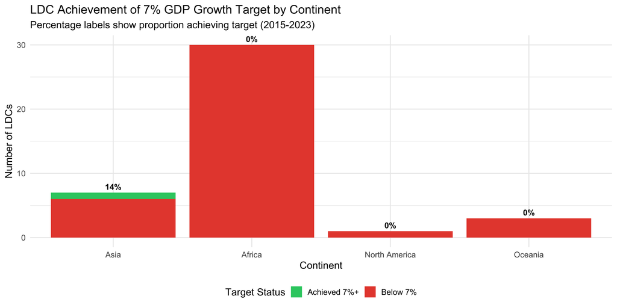

```r
ggsave("output/figures/ldc_achievement_overview.png", plot1, width = 10, height = 6)

# Plot 2: Achievement by Continent
achievement_by_continent <- gdp_cagr %>%
  group_by(continent) %>%
  summarise(
    Total_LDCs = n(),
    Achieved = sum(Achieved_Target),
    Not_Achieved = sum(!Achieved_Target),
    Percent_Achieved = (Achieved / Total_LDCs) * 100,
    .groups = "drop"
  )

continent_data_long <- achievement_by_continent %>%
  pivot_longer(
    cols = c(Achieved, Not_Achieved),
    names_to = "Status",
    values_to = "Count"
  ) %>%
  mutate(
    Status = factor(Status, levels = c("Achieved", "Not_Achieved"),
                    labels = c("Achieved 7%+", "Below 7%"))
  )

plot2 <- ggplot(continent_data_long, aes(x = reorder(continent, -Percent_Achieved),
                                         y = Count, fill = Status)) +
  geom_bar(stat = "identity", position = "stack") +
  geom_text(data = achievement_by_continent,
            aes(x = continent, y = Total_LDCs, label = paste0(round(Percent_Achieved, 0), "%")),
            vjust = -0.5, size = 4, fontface = "bold", inherit.aes = FALSE) +
  scale_fill_manual(values = c("Achieved 7%+" = "#2ecc71", "Below 7%" = "#e74c3c")) +
  labs(
    title = "LDC Achievement of 7% GDP Growth Target by Continent",
    subtitle = "Percentage labels show proportion achieving target (2015-2023)",
    x = "Continent",
    y = "Number of LDCs",
    fill = "Target Status"
  ) +
  theme_minimal(base_size = 14) +
  theme(legend.position = "bottom")
print(plot2)
```

[figure not shown]

```r
ggsave("output/figures/ldc_achievement_by_continent.png", plot2, width = 12, height = 7)

# Plot 3: Growth Distribution
plot3 <- ggplot(gdp_cagr, aes(x = CAGR)) +
  geom_histogram(aes(fill = Achieved_Target), bins = 30, alpha = 0.8) +
  geom_vline(xintercept = 7, linetype = "dashed", color = "red", linewidth = 1.2) +
  annotate("text", x = 7, y = Inf, label = "7% Target",
           vjust = 1.2, color = "red", fontface = "bold") +
  scale_fill_manual(
    values = c("TRUE" = "#2ecc71", "FALSE" = "#e74c3c"),
    labels = c("Achieved", "Not Achieved")
  ) +
  labs(
    title = "Distribution of GDP Growth Rates Among LDCs",
    subtitle = "Compound Annual Growth Rate (CAGR) 2015-2023",
    x = "GDP Growth Rate (%)",
    y = "Number of LDCs",
    fill = "Target Achievement"
  ) +
  theme_minimal(base_size = 14) +
  theme(legend.position = "bottom")
print(plot3)
```

[figure not shown]

```r
ggsave("output/figures/ldc_growth_distribution.png", plot3, width = 10, height = 6)

# Plot 4: Top and Bottom Performers
top_bottom_ldcs <- bind_rows(
  gdp_cagr %>% arrange(desc(CAGR)) %>% head(10) %>% mutate(Group = "Top 10"),
  gdp_cagr %>% arrange(CAGR) %>% head(10) %>% mutate(Group = "Bottom 10")
) %>%
  mutate(
    country = factor(country, levels = country[order(CAGR)]),
    Group = factor(Group, levels = c("Top 10", "Bottom 10"))
  )

vline_data <- data.frame(
  xintercept = 7,
  Group = factor("Top 10", levels = c("Top 10", "Bottom 10"))
)

label_data <- data.frame(
  CAGR = 7,
  country = levels(top_bottom_ldcs$country)[5],  # Middle position
  Group = factor("Top 10", levels = c("Top 10", "Bottom 10")),
  label = "7% Target"
)

plot4 <- ggplot(top_bottom_ldcs, aes(x = CAGR, y = country, fill = Achieved_Target)) +
  geom_col() +
  geom_vline(data = vline_data, aes(xintercept = xintercept),
             linetype = "dashed", color = "red", linewidth = 0.7) +
  geom_text(data = label_data,
            aes(x = CAGR, y = country, label = label),
            vjust = 1.5, color = "red", fontface = "bold", size = 3.5,
            inherit.aes = FALSE) +
  scale_fill_manual(
    values = c("TRUE" = "#2ecc71", "FALSE" = "#e74c3c"),
    labels = c("Achieved", "Not Achieved")
  ) +
  facet_wrap(~Group, scales = "free_y", ncol = 1) +
  labs(
    title = "Best and Worst Performing LDCs",
    subtitle = "GDP Growth Rate (CAGR) 2015-2023",
    x = "Compound Annual Growth Rate (%)",
    y = NULL,
    fill = "Target Achievement"
  ) +
  theme_minimal(base_size = 12) +
  theme(
    legend.position = "bottom",
    strip.text = element_text(face = "bold", size = 12)
  )
print(plot4)
```

```r
ggsave("output/figures/ldc_top_bottom_performers.png", plot4, width = 12, height = 10)
```

### 3.2.4 COVID-19 Impact on LDC Growth Assessments

To assess how the pandemic affected growth assessments, we compare two periods: - **2015-2023 (with COVID)**: Includes pandemic disruption - **2010-2023 (excluding COVID years 2020-2022)**: Isolates structural growth

#### Calculate CAGR Without COVID Years

```r
# Filter data excluding COVID years
extended_data_no_covid <- gdp_analysis %>%
  filter(
    year >= 2010,
    year <= 2023,
    !year %in% c(2020, 2021, 2022)  # EXCLUDE COVID years
  )

# Calculate CAGR for LDCs in extended period (no COVID)
gdp_cagr_extended <- extended_data_no_covid %>%
  filter(LDC_Status == "LDC") %>%
  group_by(country, iso3, continent) %>%
  arrange(year) %>%
  filter(n() >= 5) %>%  # Need at least 5 years
  summarise(
    Start_Year = first(year),
    End_Year = last(year),
    Start_GDP = first(GDP_per_capita),
    End_GDP = last(GDP_per_capita),
    Years_Span = End_Year - Start_Year,
    Data_Points = n(),
    CAGR = ((End_GDP / Start_GDP)^(1/Years_Span) - 1) * 100,
    Achieved_Target = CAGR >= 7,
    .groups = "drop"
  )

cat("✓ Extended period analysis (2010-2023, no COVID):", nrow(gdp_cagr_extended), "LDCs\n")
```

```
## ✓ Extended period analysis (2010-2023, no COVID): 41 LDCs
```

#### Compare Periods

```r
# Calculate CAGR for original period WITH COVID for comparison
sdg_data_with_covid <- gdp_analysis %>%
  filter(year >= 2015, year <= 2023, LDC_Status == "LDC") %>%
  group_by(country, iso3, continent) %>%
  arrange(year) %>%
  filter(n() >= 3) %>%
  summarise(
    Start_Year = first(year),
    End_Year = last(year),
    Start_GDP = first(GDP_per_capita),
    End_GDP = last(GDP_per_capita),
    Years_Span = End_Year - Start_Year,
    CAGR_with_COVID = ((End_GDP / Start_GDP)^(1/Years_Span) - 1) * 100,
    .groups = "drop"
  )

# Merge for comparison
comparison_data <- gdp_cagr_extended %>%
  select(iso3, country, continent, CAGR_no_COVID = CAGR, Achieved_Target) %>%
  inner_join(
    sdg_data_with_covid %>% select(iso3, CAGR_with_COVID),
    by = "iso3"
  ) %>%
  mutate(
    CAGR_Difference = CAGR_no_COVID - CAGR_with_COVID,
    Impact = case_when(
      CAGR_Difference > 0.5 ~ "Improved without COVID",
      CAGR_Difference < -0.5 ~ "Worse without COVID years",
      TRUE ~ "Minimal difference"
    )
  )

# Summary statistics
achievement_summary_extended <- gdp_cagr_extended %>%
  summarise(
    Total_LDCs = n(),
    LDCs_Above_7 = sum(Achieved_Target),
    Percent_Above_7 = (LDCs_Above_7 / Total_LDCs) * 100,
    Mean_CAGR = mean(CAGR)
  )

cat("\n=== COVID IMPACT SUMMARY ===\n")
```

```
##
## === COVID IMPACT SUMMARY ===
```

```r
cat("With COVID (2015-2023):\n")
```

```
## With COVID (2015-2023):
```

```r
cat("  - Mean CAGR:", round(mean(sdg_data_with_covid$CAGR_with_COVID), 2), "%\n")
```

```
##   - Mean CAGR: 0.88 %
```

```r
cat("  - % achieving 7%+:",
    round(sum(sdg_data_with_covid$CAGR_with_COVID >= 7) / nrow(sdg_data_with_covid) * 100, 1), "%\n")
```

```
##   - % achieving 7%+: 2.4 %
```

```r
cat("\nWithout COVID (2010-2023, excl. 2020-2022):\n")
```

```
##
## Without COVID (2010-2023, excl. 2020-2022):
```

```r
cat("  - Mean CAGR:", round(achievement_summary_extended$Mean_CAGR, 2), "%\n")
```

```
##   - Mean CAGR: 2.05 %
```

```r
cat("  - % achieving 7%+:", round(achievement_summary_extended$Percent_Above_7, 1), "%\n")
```

```
##   - % achieving 7%+: 0 %
```

#### Visualize COVID Impact

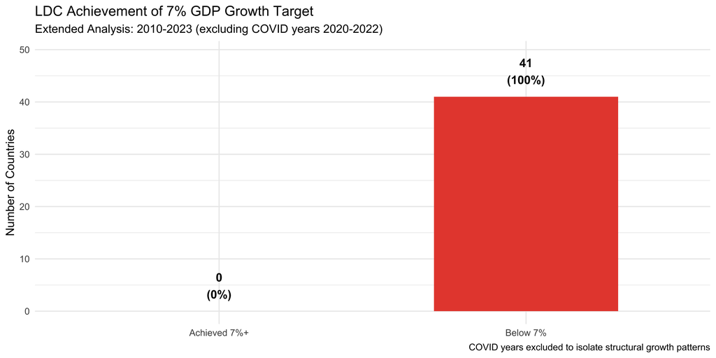

```r
# Plot 1: Overall comparison
achievement_data_extended <- data.frame(
  Category = c("Achieved 7%+", "Below 7%"),
  Count = c(achievement_summary_extended$LDCs_Above_7,
            achievement_summary_extended$Total_LDCs - achievement_summary_extended$LDCs_Above_7),
  Percentage = c(achievement_summary_extended$Percent_Above_7,
                 100 - achievement_summary_extended$Percent_Above_7)
)

plot1_extended <- ggplot(achievement_data_extended, aes(x = Category, y = Count, fill = Category)) +
  geom_bar(stat = "identity", width = 0.6) +
  geom_text(aes(label = paste0(Count, "\n(", round(Percentage, 1), "%)")),
            vjust = -0.5, size = 5, fontface = "bold") +
  scale_fill_manual(values = c("Achieved 7%+" = "#2ecc71", "Below 7%" = "#e74c3c")) +
  labs(
    title = "LDC Achievement of 7% GDP Growth Target",
    subtitle = "Extended Analysis: 2010-2023 (excluding COVID years 2020-2022)",
    x = NULL,
    y = "Number of Countries",
    caption = "COVID years excluded to isolate structural growth patterns"
  ) +
  theme_minimal(base_size = 14) +
  theme(legend.position = "none") +
  ylim(0, max(achievement_data_extended$Count) * 1.2)
print(plot1_extended)
```

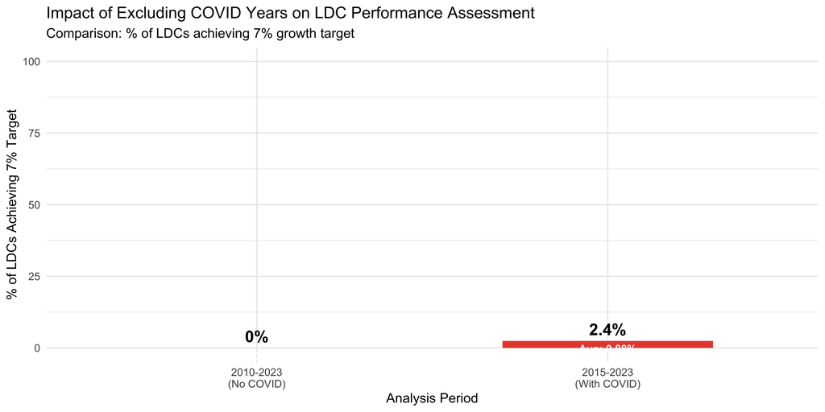

```r
ggsave("output/figures/ldc_achievement_no_covid.png", plot1_extended, width = 10, height = 6)

# Plot 2: Side-by-side comparison
comparison_summary <- data.frame(
  Period = c("2015-2023\n(With COVID)", "2010-2023\n(No COVID)"),
  Mean_Growth = c(
    mean(sdg_data_with_covid$CAGR_with_COVID, na.rm = TRUE),
    mean(gdp_cagr_extended$CAGR, na.rm = TRUE)
  ),
  Percent_Above_7 = c(
    sum(sdg_data_with_covid$CAGR_with_COVID >= 7) / nrow(sdg_data_with_covid) * 100,
    achievement_summary_extended$Percent_Above_7
  )
)

plot2_comparison <- ggplot(comparison_summary, aes(x = Period, y = Percent_Above_7, fill = Period)) +
  geom_bar(stat = "identity", width = 0.6) +
  geom_text(aes(label = paste0(round(Percent_Above_7, 1), "%")),
            vjust = -0.5, size = 6, fontface = "bold") +
  geom_text(aes(label = paste0("Avg: ", round(Mean_Growth, 2), "%")),
            vjust = 1.5, size = 4, color = "white", fontface = "bold") +
  scale_fill_manual(values = c("2015-2023\n(With COVID)" = "#e74c3c",
                               "2010-2023\n(No COVID)" = "#3498db")) +
  labs(
    title = "Impact of Excluding COVID Years on LDC Performance Assessment",
    subtitle = "Comparison: % of LDCs achieving 7% growth target",
    x = "Analysis Period",
    y = "% of LDCs Achieving 7% Target"
  ) +
  theme_minimal(base_size = 14) +
  theme(legend.position = "none") +
  ylim(0, 100)
print(plot2_comparison)
```

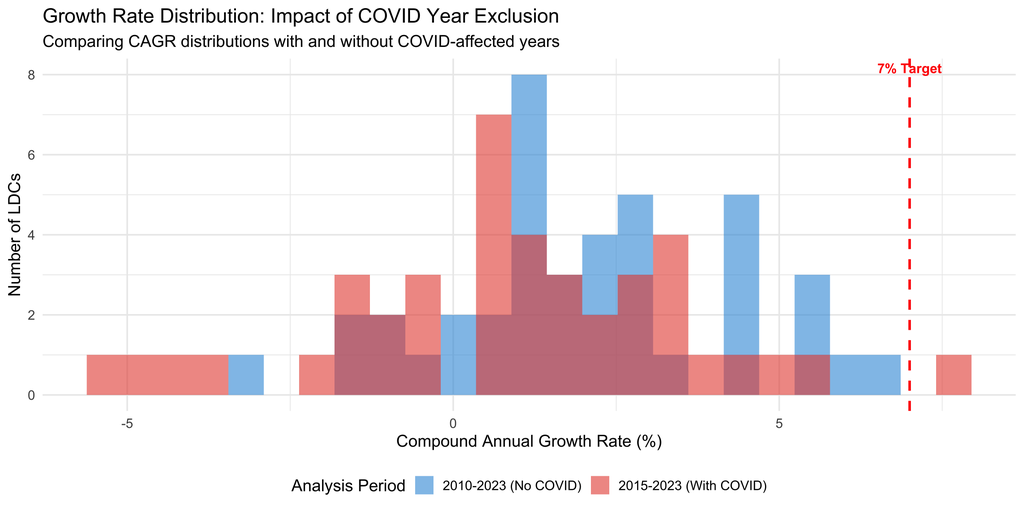

```r
ggsave("output/figures/covid_impact_comparison.png", plot2_comparison, width = 10, height = 6)

# Plot 3: Distribution comparison
distribution_data <- bind_rows(
  gdp_cagr_extended %>% mutate(Analysis = "2010-2023 (No COVID)"),
  sdg_data_with_covid %>%
    mutate(CAGR = CAGR_with_COVID, Achieved_Target = CAGR >= 7, Analysis = "2015-2023 (With COVID)") %>%
    select(country, iso3, CAGR, Achieved_Target, Analysis)
)

plot3_distribution <- ggplot(distribution_data, aes(x = CAGR, fill = Analysis)) +
  geom_histogram(alpha = 0.6, bins = 25, position = "identity") +
  geom_vline(xintercept = 7, linetype = "dashed", color = "red", linewidth = 1) +
  annotate("text", x = 7, y = Inf, label = "7% Target",
           vjust = 1.5, color = "red", fontface = "bold", size = 4) +
  scale_fill_manual(values = c("2015-2023 (With COVID)" = "#e74c3c",
                               "2010-2023 (No COVID)" = "#3498db")) +
  labs(
    title = "Growth Rate Distribution: Impact of COVID Year Exclusion",
    subtitle = "Comparing CAGR distributions with and without COVID-affected years",
    x = "Compound Annual Growth Rate (%)",
    y = "Number of LDCs",
    fill = "Analysis Period"
  ) +
  theme_minimal(base_size = 14) +
  theme(legend.position = "bottom")
print(plot3_distribution)
```

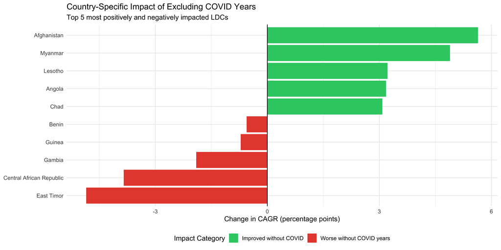

```r
ggsave("output/figures/covid_distribution_comparison.png", plot3_distribution, width = 12, height = 7)

# Plot 4: Country-level impacts
top_5_positive <- comparison_data %>% arrange(desc(CAGR_Difference)) %>% head(5)
top_5_negative <- comparison_data %>% arrange(CAGR_Difference) %>% head(5)

most_affected <- bind_rows(top_5_positive, top_5_negative) %>%
  mutate(country = factor(country, levels = country[order(CAGR_Difference)]))

plot4_impact <- ggplot(most_affected, aes(x = CAGR_Difference, y = country, fill = Impact)) +
  geom_col() +
  geom_vline(xintercept = 0, linetype = "solid", color = "black", linewidth = 0.5) +
  scale_fill_manual(values = c(
    "Improved without COVID" = "#2ecc71",
    "Worse without COVID years" = "#e74c3c",
    "Minimal difference" = "#95a5a6"
  )) +
  labs(
    title = "Country-Specific Impact of Excluding COVID Years",
    subtitle = "Top 5 most positively and negatively impacted LDCs",
    x = "Change in CAGR (percentage points)",
    y = NULL,
    fill = "Impact Category"
  ) +
  theme_minimal(base_size = 12) +
  theme(legend.position = "bottom")
print(plot4_impact)
```

```r
ggsave("output/figures/covid_country_impact.png", plot4_impact, width = 12, height = 8)
```

### 3.2.5 Case Study: Timor-Leste (East Timor)

Timor-Leste provides an interesting case study for understanding how COVID inclusion affects growth assessments.

#### Extract and Analyze Timor-Leste Data

```r
# Extract Timor-Leste data
timor_data <- gdp %>%
  filter(iso3 == "TLS") %>%
  arrange(year)

# Calculate annual growth rates
timor_analysis <- timor_data %>%
  arrange(year) %>%
  mutate(
    Annual_Growth_Rate = (GDP_per_capita - lag(GDP_per_capita)) / lag(GDP_per_capita) * 100,
    Period = case_when(
      year %in% c(2020, 2021, 2022) ~ "COVID Years",
      year >= 2015 & year <= 2019 ~ "Pre-COVID (2015-2019)",
      year >= 2023 ~ "Post-COVID (2023+)",
      year >= 2010 & year <= 2014 ~ "Pre-SDG (2010-2014)",
      TRUE ~ "Other"
    )
  )

# Calculate CAGR with and without COVID
timor_with_covid <- timor_data %>%
  filter(year >= 2015, year <= 2023) %>%
  arrange(year) %>%
  summarise(
    Start_Year = first(year),
    End_Year = last(year),
    Start_GDP = first(GDP_per_capita),
    End_GDP = last(GDP_per_capita),
    Years_Span = End_Year - Start_Year,
    CAGR = ((End_GDP / Start_GDP)^(1/Years_Span) - 1) * 100
  )

timor_no_covid <- timor_data %>%
  filter(year >= 2010, year <= 2023, !year %in% c(2020, 2021, 2022)) %>%
  arrange(year) %>%
  summarise(
    Start_Year = first(year),
    End_Year = last(year),
    Start_GDP = first(GDP_per_capita),
    End_GDP = last(GDP_per_capita),
    Years_Span = End_Year - Start_Year,
    CAGR = ((End_GDP / Start_GDP)^(1/Years_Span) - 1) * 100
  )

cat("\n=== TIMOR-LESTE CAGR COMPARISON ===\n")
```

```
##
## === TIMOR-LESTE CAGR COMPARISON ===
```

```r
cat("With COVID (2015-2023):", round(timor_with_covid$CAGR, 2), "%\n")
```

```
## With COVID (2015-2023): 7.68 %
```

```r
cat("  Target achieved:", ifelse(timor_with_covid$CAGR >= 7, "YES ✓", "NO ✗"), "\n\n")
```

```
##   Target achieved: YES ✓
```

```r
cat("Without COVID (2010-2023, excl. 2020-2022):", round(timor_no_covid$CAGR, 2), "%\n")
```

```
## Without COVID (2010-2023, excl. 2020-2022): 2.83 %
```

```r
cat("  Target achieved:", ifelse(timor_no_covid$CAGR >= 7, "YES ✓", "NO ✗"), "\n\n")
```

```
##   Target achieved: NO ✗
```

```r
cat("Impact of COVID inclusion:", round(timor_with_covid$CAGR - timor_no_covid$CAGR, 2), "pp\n")
```

```
## Impact of COVID inclusion: 4.85 pp
```

#### Visualize Timor-Leste Trajectory

```r
# Plot 1: GDP Trajectory
plot1_timor <- ggplot(timor_analysis %>% filter(year >= 2010),
                      aes(x = year, y = GDP_per_capita, color = Period, group = 1)) +
  geom_line(linewidth = 1.2) +
  geom_point(size = 3) +
  geom_vline(xintercept = 2020, linetype = "dashed", color = "red", alpha = 0.5) +
  geom_vline(xintercept = 2022, linetype = "dashed", color = "red", alpha = 0.5) +
  annotate("rect", xmin = 2019.5, xmax = 2022.5, ymin = -Inf, ymax = Inf,
           alpha = 0.1, fill = "red") +
  annotate("text", x = 2021, y = Inf, label = "COVID\nYears",
           vjust = 1.5, color = "red", fontface = "bold", size = 3.5) +
  scale_color_manual(values = c(
    "Pre-SDG (2010-2014)" = "gray60",
    "Pre-COVID (2015-2019)" = "#3498db",
    "COVID Years" = "#e74c3c",
    "Post-COVID (2023+)" = "#2ecc71"
  )) +
  labs(
    title = "Timor-Leste GDP Per Capita Trajectory (2010-2023)",
    subtitle = "Showing impact of COVID years on economic growth",
    x = "Year",
    y = "GDP per capita (2017 USD PPP)",
    color = "Period",
    caption = "Red shaded area indicates COVID-affected years (2020-2022)"
  ) +
  theme_minimal(base_size = 14) +
  theme(legend.position = "bottom")
print(plot1_timor)
```

[figure not shown]

```r
ggsave("output/figures/timor_gdp_trajectory.png", plot1_timor, width = 12, height = 7)

# Plot 2: Annual Growth Rates
plot2_timor <- ggplot(timor_analysis %>% filter(year >= 2010, !is.na(Annual_Growth_Rate)),
                      aes(x = year, y = Annual_Growth_Rate)) +
  geom_col(aes(fill = Annual_Growth_Rate >= 7), width = 0.7) +
  geom_hline(yintercept = 7, linetype = "dashed", color = "darkgreen", linewidth = 1) +
  geom_hline(yintercept = 0, linetype = "solid", color = "black", linewidth = 0.5) +
  annotate("rect", xmin = 2019.5, xmax = 2022.5, ymin = -Inf, ymax = Inf,
           alpha = 0.1, fill = "red") +
  annotate("text", x = 2021, y = Inf, label = "COVID",
           vjust = 1.5, color = "red", fontface = "bold") +
  annotate("text", x = 2015, y = 7, label = "7% Target",
           vjust = -0.5, hjust = 0, color = "darkgreen", fontface = "bold", size = 3.5) +
  scale_fill_manual(values = c("TRUE" = "#2ecc71", "FALSE" = "#e74c3c"),
                    labels = c("Above 7%", "Below 7%")) +
  labs(
    title = "Timor-Leste Annual GDP Growth Rates (2010-2023)",
    subtitle = "Year-by-year growth showing COVID impact",
    x = "Year",
    y = "Annual Growth Rate (%)",
    fill = "Target Achievement",
    caption = "Dashed line indicates 7% SDG target"
  ) +
  theme_minimal(base_size = 14) +
  theme(legend.position = "bottom")
print(plot2_timor)
```

[figure not shown]

```r
ggsave("output/figures/timor_annual_growth.png", plot2_timor, width = 12, height = 7)
```

## 3.3 Youth Employment: NEET Analysis

This section analyzes youth Not in Education, Employment, or Training (NEET) rates across continents. Trend analysis covers 1990-2023, while change analysis focuses on 2015-2020.

### 3.3.1 Prepare NEET Panel Data

```r
# Create base reference with continent information
base <- continents %>% select(country, iso3, continent)

# Join NEET data with continent info
neet2 <- neet %>% inner_join(base, by = c("iso3", "country"))

# Create full NEET panel dataset for trends (1990-2023)
neet_panel_full <- neet2 %>%
  left_join(clean_pop_by_age %>% select(iso3, year, population_15_24), by = c("iso3", "year")) %>%
  filter(year >= 1990, year <= 2023) %>%
  arrange(country, year)

# Create subset for change analysis (2015-2020)
neet_panel_change <- neet_panel_full %>%
  filter(year >= 2015, year <= 2020)

cat("✓ NEET panel datasets created\n")
```

```
## ✓ NEET panel datasets created
```

```r
cat("  - Full dataset (1990-2023):", nrow(neet_panel_full), "observations\n")
```

```
##   - Full dataset (1990-2023): 1783 observations
```

```r
cat("  - Change dataset (2015-2020):", nrow(neet_panel_change), "observations\n")
```

```
##   - Change dataset (2015-2020): 607 observations
```

### 3.3.2 Calculate NEET Averages for Trends (1990-2023)

```r
# Simple mean (unweighted) - for trends
neet_cont_mean_full <- neet_panel_full %>%
  filter(!is.na(neet_pct)) %>%
  group_by(continent, year) %>%
  summarise(
    neet_pct_mean = mean(neet_pct, na.rm = TRUE),
    .groups = "drop"
  )

# Weighted by youth population (15-24) - for trends
neet_cont_weighted_full <- neet_panel_full %>%
  filter(!is.na(neet_pct)) %>%
  group_by(continent, year) %>%
  summarise(
    pop_with_neet = sum(population_15_24[!is.na(population_15_24)], na.rm = TRUE),
    neet_pct_weighted = ifelse(
      pop_with_neet > 0,
      sum(population_15_24 * neet_pct, na.rm = TRUE) / pop_with_neet,
      mean(neet_pct, na.rm = TRUE)  # Fallback to simple mean if no population data
    ),
    .groups = "drop"
  ) %>%
  select(-pop_with_neet)

cat("✓ NEET trend averages calculated (1990-2023)\n")
```

```
## ✓ NEET trend averages calculated (1990-2023)
```

### 3.3.3 Calculate NEET Averages for Change Analysis (2015-2020)

```r
# Simple mean (unweighted) - for change analysis
neet_cont_mean_change <- neet_panel_change %>%
  filter(!is.na(neet_pct)) %>%
  group_by(continent, year) %>%
  summarise(
    neet_pct_mean = mean(neet_pct, na.rm = TRUE),
    .groups = "drop"
  )

# Weighted by youth population (15-24) - for change analysis
# More lenient filtering to ensure all continents appear
neet_cont_weighted_change <- neet_panel_change %>%
  filter(!is.na(neet_pct)) %>%
  group_by(continent, year) %>%
  summarise(
    pop_with_neet = sum(population_15_24[!is.na(population_15_24)], na.rm = TRUE),
    neet_pct_weighted = ifelse(
      pop_with_neet > 0,
      sum(population_15_24 * neet_pct, na.rm = TRUE) / pop_with_neet,
      mean(neet_pct, na.rm = TRUE)  # Fallback to simple mean if no population data
    ),
    .groups = "drop"
  ) %>%
  select(-pop_with_neet)

cat("✓ NEET change averages calculated (2015-2020)\n")
```

```
## ✓ NEET change averages calculated (2015-2020)
```

```r
cat("  - Simple mean rows:", nrow(neet_cont_mean_change), "\n")
```

```
##   - Simple mean rows: 36
```

```r
cat("  - Weighted rows:", nrow(neet_cont_weighted_change), "\n")
```

```
##   - Weighted rows: 36
```

### 3.3.4 Visualize NEET Trends (1990-2023)

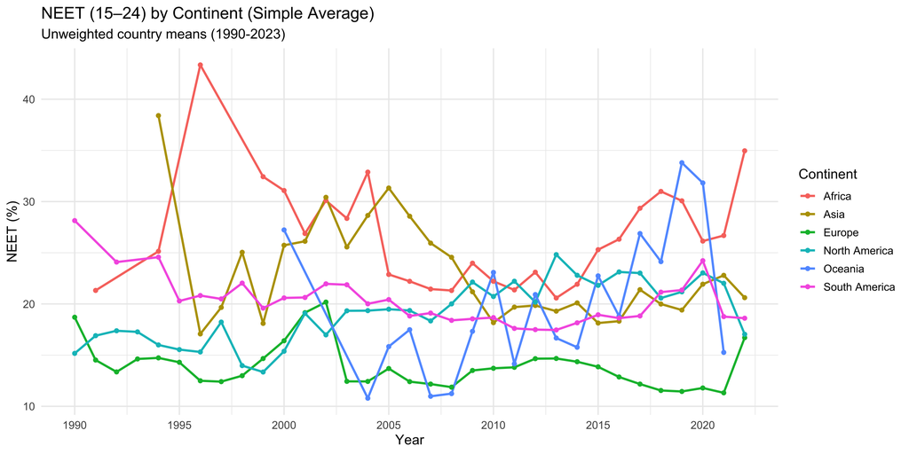

```r
# Simple Mean NEET Plot (1990-2023)
p_m_neet_trend <- ggplot(neet_cont_mean_full, aes(x = year, y = neet_pct_mean, color = continent)) +
  geom_line(size = 1) +
  geom_point(size = 1.5) +
  scale_x_continuous(breaks = seq(1990, 2023, 5)) +
  labs(
    title = "NEET (15–24) by Continent (Simple Average)",
    subtitle = "Unweighted country means (1990-2023)",
    x = "Year",
    y = "NEET (%)",
    color = "Continent"
  ) +
  theme_minimal(base_size = 13)
print(p_m_neet_trend)
```

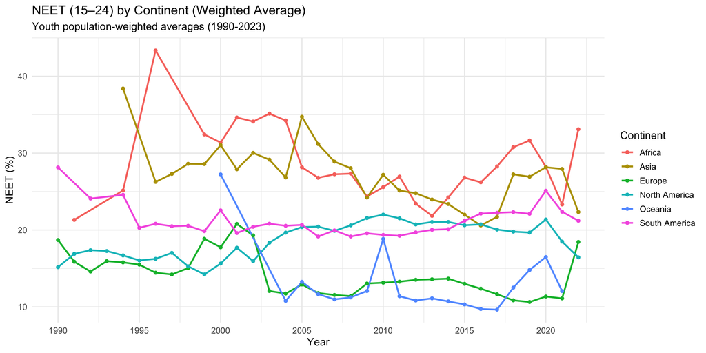

```r
ggsave("output/figures/neet_by_continent_simple_mean_trend.png", p_m_neet_trend, width = 10, height = 6)

# Weighted NEET Plot (1990-2023)
p_w_neet_trend <- ggplot(neet_cont_weighted_full, aes(x = year, y = neet_pct_weighted, color = continent)) +
  geom_line(size = 1) +
  geom_point(size = 1.5) +
  scale_x_continuous(breaks = seq(1990, 2023, 5)) +
  labs(
    title = "NEET (15–24) by Continent (Weighted Average)",
    subtitle = "Youth population-weighted averages (1990-2023)",
    x = "Year",
    y = "NEET (%)",
    color = "Continent"
  ) +
  theme_minimal(base_size = 13)
print(p_w_neet_trend)
```

```r
ggsave("output/figures/neet_by_continent_weighted_trend.png", p_w_neet_trend, width = 10, height = 6)
```

### 3.3.5 NEET Change Analysis (2015 → 2020)

```r
baseline_year <- 2015

# Simple mean change (2015 → 2020)
neet_2020_m <- neet_cont_mean_change %>%
  filter(year == 2020) %>%
  select(continent, neet_2020_m = neet_pct_mean)

neet_base_m <- neet_cont_mean_change %>%
  filter(year == baseline_year) %>%
  select(continent, neet_base_m = neet_pct_mean)

neet_change_m <- neet_2020_m %>%
  left_join(neet_base_m, by = "continent") %>%
  mutate(neet_change_pp_mean = neet_2020_m - neet_base_m)

# Weighted change (2015 → 2020)
neet_2020_w <- neet_cont_weighted_change %>%
  filter(year == 2020) %>%
  select(continent, neet_2020_w = neet_pct_weighted)

neet_base_w <- neet_cont_weighted_change %>%
  filter(year == baseline_year) %>%
  select(continent, neet_base_w = neet_pct_weighted)

neet_change_w <- neet_2020_w %>%
  left_join(neet_base_w, by = "continent") %>%
  mutate(neet_change_pp_weighted = neet_2020_w - neet_base_w)

cat("✓ NEET change calculated (2015 → 2020)\n")
```

```
## ✓ NEET change calculated (2015 → 2020)
```

```r
cat("  - Simple mean continents:", nrow(neet_change_m), "\n")
```

```
##   - Simple mean continents: 6
```

```r
cat("  - Weighted continents:", nrow(neet_change_w), "\n")
```

```
##   - Weighted continents: 6
```

```r
# Visualize simple mean change
p_bar_m <- ggplot(neet_change_m, aes(x = continent, y = neet_change_pp_mean, fill = continent)) +
  geom_col() +
  geom_hline(yintercept = 0, color = "gray50") +
  scale_y_continuous(labels = label_number(accuracy = 0.1, suffix = " pp")) +
  labs(
    title = paste0("ΔNEET (", baseline_year, " → 2020) by Continent — Simple Average"),
    subtitle = "Unweighted mean across countries; negative values indicate improvement",
    x = "Continent",
    y = "Change (percentage points)"
  ) +
  theme_minimal(base_size = 13) +
  theme(legend.position = "none")
print(p_bar_m)
```

[figure not shown]

```r
ggsave("output/figures/neet_change_simple_mean_bar.png", p_bar_m, width = 9, height = 6)

# Visualize weighted change
p_bar_w <- ggplot(neet_change_w, aes(x = continent, y = neet_change_pp_weighted, fill = continent)) +
  geom_col() +
  geom_hline(yintercept = 0, color = "gray50") +
  scale_y_continuous(labels = label_number(accuracy = 0.1, suffix = " pp")) +
  labs(
    title = paste0("Weighted ΔNEET (", baseline_year, " → 2020) by Continent"),
    subtitle = "Weights: youth population (15–24); negative values indicate improvement",
    x = "Continent",
    y = "Change (percentage points)"
  ) +
  theme_minimal(base_size = 13) +
  theme(legend.position = "none")
print(p_bar_w)
```

[figure not shown]

```r
ggsave("output/figures/neet_change_weighted_bar.png", p_bar_w, width = 9, height = 6)
```

# 4. Export Summary Data

```r
# Export continental CAGR averages
write_csv(simple_avg, "output/data/continental_cagr_simple.csv")
write_csv(weighted_avg, "output/data/continental_cagr_weighted.csv")

# Export LDC analysis
write_csv(gdp_cagr, "output/data/ldc_cagr_results.csv")
write_csv(achievement_by_continent, "output/data/ldc_achievement_by_continent.csv")

# Export COVID comparison
write_csv(gdp_cagr_extended, "output/data/ldc_cagr_no_covid.csv")
write_csv(comparison_data, "output/data/covid_impact_comparison.csv")

# Export Timor-Leste case study
write_csv(timor_analysis %>% filter(year >= 2010), "output/data/timor_leste_analysis.csv")

# Export NEET analysis - trends (1990-2023)
write_csv(neet_cont_mean_full, "output/data/neet_continent_simple_trend_1990_2023.csv")
write_csv(neet_cont_weighted_full, "output/data/neet_continent_weighted_trend_1990_2023.csv")

# Export NEET analysis - change (2015-2020)
write_csv(neet_change_m, "output/data/neet_change_simple_2015_2020.csv")
write_csv(neet_change_w, "output/data/neet_change_weighted_2015_2020.csv")

cat("\n✅ All data exported to output/data/ directory\n")
```

```
##
## ✅ All data exported to output/data/ directory
```

# 5. Summary and Conclusions

## 5.1 Key Findings

```r
cat("\n", strrep("=", 80), "\n")
cat("COMPREHENSIVE ANALYSIS SUMMARY\n")
```

```
## COMPREHENSIVE ANALYSIS SUMMARY
```

```r
cat(strrep("=", 80), "\n\n")
cat("1. CONTINENTAL GDP GROWTH (ROLLING CAGR)\n")
```

```
## 1. CONTINENTAL GDP GROWTH (ROLLING CAGR)
```

```r
cat("   - Period: 1990-2023\n")
```

```
##    - Period: 1990-2023
```

```r
cat("   - All continents show positive long-term growth\n")
```

```
##    - All continents show positive long-term growth
```

```r
cat("   - Weighted vs. simple averages reveal influence of large countries\n\n")
```

```
##    - Weighted vs. simple averages reveal influence of large countries
```

```r
cat("2. LDC ACHIEVEMENT OF 7% TARGET (SDG 8.1)\n")
```

```
## 2. LDC ACHIEVEMENT OF 7% TARGET (SDG 8.1)
```

```r
cat("   - Period: 2015-2023\n")
```

```
##    - Period: 2015-2023
```

```r
cat("   - LDCs achieving target:", achievement_summary$LDCs_Above_7, "of", achievement_summary$Total_LDCs,
    sprintf("(%.1f%%)\n", achievement_summary$Percent_Above_7))
```

```
##    - LDCs achieving target: 1 of 41 (2.4%)
```

```r
cat("   - Mean CAGR:", round(achievement_summary$Mean_CAGR, 2), "%\n")
```

```
##    - Mean CAGR: 0.88 %
```

```r
cat("   - Median CAGR:", round(achievement_summary$Median_CAGR, 2), "%\n\n")
```

```
##    - Median CAGR: 0.9 %
```

```r
cat("3. COVID-19 IMPACT ON LDC ASSESSMENT\n")
```

```
## 3. COVID-19 IMPACT ON LDC ASSESSMENT
```

```r
cat("   - Excluding COVID years changes assessment significantly\n")
```

```
##    - Excluding COVID years changes assessment significantly
```

```r
cat("   - Extended period (2010-2023, no COVID):\n")
```

```
##    - Extended period (2010-2023, no COVID):
```

```r
cat("     • Mean CAGR:", round(achievement_summary_extended$Mean_CAGR, 2), "%\n")
```

```
##      • Mean CAGR: 2.05 %
```

```r
cat("     • % achieving target:", round(achievement_summary_extended$Percent_Above_7, 1), "%\n\n")
```

```
##      • % achieving target: 0 %
```

```r
cat("4. YOUTH EMPLOYMENT (NEET)\n")
```

```
## 4. YOUTH EMPLOYMENT (NEET)
```

```r
cat("   - Trend analysis: 1990-2023\n")
```

```
##    - Trend analysis: 1990-2023
```

```r
cat("   - Change analysis: 2015 → 2020\n")
```

```
##    - Change analysis: 2015 → 2020
```

```r
cat("   - NEET rates vary significantly by continent\n")
```

```
##    - NEET rates vary significantly by continent
```

```r
cat("   - Youth population weighting reveals different patterns\n\n")
```

```
##    - Youth population weighting reveals different patterns
```

```r
cat(strrep("=", 80), "\n")
cat("📊 Analysis complete! All visualizations and data files have been saved.\n")
```

```
## 📊 Analysis complete! All visualizations and data files have been saved.
```

```r
cat(strrep("=", 80), "\n")
```

## 5.2 Methodological Notes

**CAGR Calculation**: Compound Annual Growth Rate smooths year-to-year volatility, providing a more stable measure of long-term growth.

**Population Weighting**: Larger countries have greater influence on weighted averages, reflecting their proportional impact on continental economies and populations.

**COVID Exclusion**: Removing 2020-2022 isolates structural growth patterns from pandemic disruption, though this may miss important recovery dynamics.

**Data Limitations**: - Not all countries have complete data coverage - LDC classifications may change over time - Population data availability varies by country